# Spatiotemporal EGARCH: Application to the CAC40 stock Market

Author

Ariane N. Meli Chrisko, Philipp Otto, Wolfgang Schmid

## Exponential Spatiotemporal GARCH Model with Asymmetric Volatility Spillovers: Application to CAC40 stock market

In this analysis, we explore the spatiotemporal dependencies and volatility dynamics in stock return data using the CAC40 index as a case study. The dataset is obtained via the `BatchGetSymbols` package, retrieving daily log returns for constituent stocks over a specified period. To model the interdependencies among stocks, we apply a spatial dynamic panel data (SDPD) model for the mean process, followed by a spatiotemporal EGARCH model for the residual volatility. The network structure is captured via different dissimilarity-based spatial weight matrices, reflecting economic and statistical relationships between stocks. The same pipeline can be applied to the NYSE and DAX by simply providing the appropriate tickers for each market and replacing the `bench.ticker` argument with `"^GSPC"` for NYSE and `"^GDAXI"` for DAX, respectively. The SDPD mean model and spatiotemporal EGARCH volatility estimation can be reused without modification; only the input data Y and spatial weight matrices need to be regenerated based on the updated stock set.

## Loading packages

```r
library("rio")
library("BatchGetSymbols")
library("cluster")
library("TSclust")
library("lgarch")
library("MASS")
library("doParallel")
library(ggplot2)
library(reshape2)
library(Rsolnp)
library(classInt)
library(nleqslv)
library(Matrix)
library("igraph")
library("wesanderson")
library(spdep)
library(MTS)
library(gplots)
library(rugarch)
library(gridExtra)
library(dplyr)
```

## Data Import & Preprocessing Explain

```r
# Load data using an excel sheet containing the tickers

DJIA.dat <- rio::import("cac40_at_2020.xlsx")
tickers <- DJIA.dat$Symbol
tickers <- tickers[tickers != "STLAP.PA"]

start.date <- as.Date("2019-10-01")
end.date <- as.Date("2022-10-31")

l.out <- BatchGetSymbols(tickers = tickers,
                         first.date = start.date,
                         last.date =  end.date,
                         thresh.bad.data = 1,
                         bench.ticker = "^FCHI",
                         type.return = "log",
                         freq.data = "daily")

export(l.out,"l.out.RDS")
Datar <- unstack(l.out$df.tickers, l.out$df.tickers$ret.adjusted.prices~l.out$df.tickers$ticker)
Datar <- Datar[-1,]

train.l <-  731  # fitting the model on two years data

# Adjust data in a proper way (replacing null values by randon N(0,0.001))
logDatar2 <- Datar[1:train.l, ]

cat("Standard deviation of returns over the considered period :\n")
```

```
Standard deviation of returns over the considered period :
```

```r
print(apply(logDatar2, 2, sd))
```

```
     AC.PA     ACA.PA      AI.PA     AIR.PA      BN.PA     BNP.PA      CA.PA
0.02817621 0.02512889 0.01475906 0.03250337 0.01559688 0.02669043 0.01853145
    CAP.PA      CS.PA      DG.PA     DSY.PA    EDEN.PA      EL.PA      EN.PA
0.02123517 0.02062180 0.02362652 0.01916417 0.01995751 0.01868678 0.02169503
   ENGI.PA     ERF.PA     GLE.PA      HO.PA     KER.PA      LR.PA      MC.PA
0.01999689 0.02226970 0.03172741 0.02135873 0.02178285 0.01774548 0.01974913
     ML.PA      OR.PA     ORA.PA     PUB.PA      RI.PA     RMS.PA     RNO.PA
0.02002505 0.01673834 0.01423807 0.02408688 0.01504267 0.01829036 0.03513630
    SAF.PA     SAN.PA     SGO.PA   STMPA.PA      SU.PA     TEP.PA     TTE.PA
0.03143686 0.01425019 0.02371443 0.02643092 0.01972118 0.02041121 0.02360440
    VIE.PA     VIV.PA
0.02169013 0.01791608
```

```r
# Initialize a vector to store zero counts per column
zero_counts <- ncol(logDatar2)

#  count zeros and replace random
for (i in 1:ncol(logDatar2)) {
  zero_counts[i] <- sum(logDatar2[, i] == 0)  # Count zero values in each column
  logDatar2[, i] <- ifelse(logDatar2[, i] == 0, rnorm(1, 0, 0.001), logDatar2[, i])
}

# Get names of columns with non-zero counts of zeros
columns_with_zeros <- zero_counts[zero_counts > 0]
names(columns_with_zeros) <- colnames(logDatar2)[zero_counts > 0]

cat("Stocks with returns equal to zero on some days:\n")
```

```
Stocks with returns equal to zero on some days:
```

```r
print(columns_with_zeros)
```

```
   AC.PA   ACA.PA    AI.PA   AIR.PA    BN.PA   BNP.PA    CA.PA   CAP.PA
       2        5       11        2        6        2        9       18
   CS.PA    DG.PA   DSY.PA  EDEN.PA    EL.PA    EN.PA  ENGI.PA   ERF.PA
       8        6        8        7        6        6        2        5
  GLE.PA    HO.PA   KER.PA    LR.PA    MC.PA    ML.PA    OR.PA   ORA.PA
       6        4        4        1        7       10        6        9
  PUB.PA    RI.PA   RMS.PA   RNO.PA   SAF.PA   SAN.PA   SGO.PA STMPA.PA
      12        8        9        4        6        3        4        3
   SU.PA   TEP.PA   TTE.PA   VIE.PA   VIV.PA
       6       11        3       12       12
```

```r
cat("\nPercentage of zero returns in the dataset: ",
    round((sum(zero_counts) / (nrow(logDatar2) * ncol(logDatar2))) * 100, 3), "%\n")
```

```
Percentage of zero returns in the dataset:  0.898 %
```

```r
cat("Dimensions of logDatar2: ", paste(dim(logDatar2), collapse = " x "), "\n")
```

```
Dimensions of logDatar2:  731 x 37
```

## Data Visualization

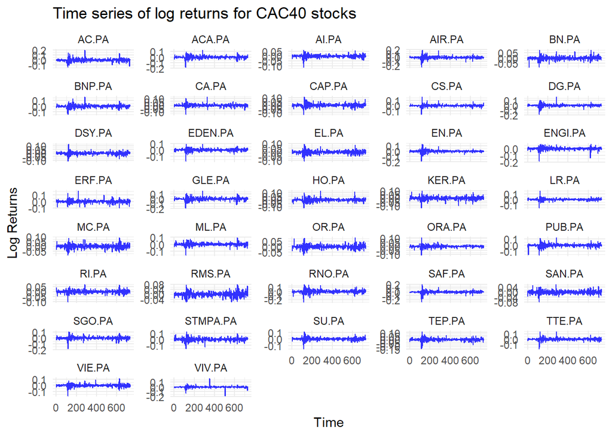

```r
# Create a data frame with an additional 'Time' column to represent the sequence of dates or time points
df <- data.frame(Time = 1:nrow(logDatar2), logDatar2)

# Melt the data frame to long format for ggplot
df_melted <- melt(df, id.vars = "Time")


# Plot using ggplot2
ggplot(df_melted, aes(x = Time, y = value)) +
  geom_line(color = "blue", alpha = 0.8) +
  labs(title = "Time series of log returns for CAC40 stocks",
       x = "Time",
       y = "Log Returns") +
  theme_minimal() +
  facet_wrap(~ variable, scales = "free_y", ncol = 5)  # Adjust ncol to control the number of columns
```

## Matrix Construction and Network Definition

$$w_{ij} =
\begin{cases}
\frac{1}{k}, & \text{if } i \text{ is among the } k \text{ nearest neighbours of } j \\
0, & \text{otherwise}
\end{cases}$$

In our implementation, we set $k = 5$.

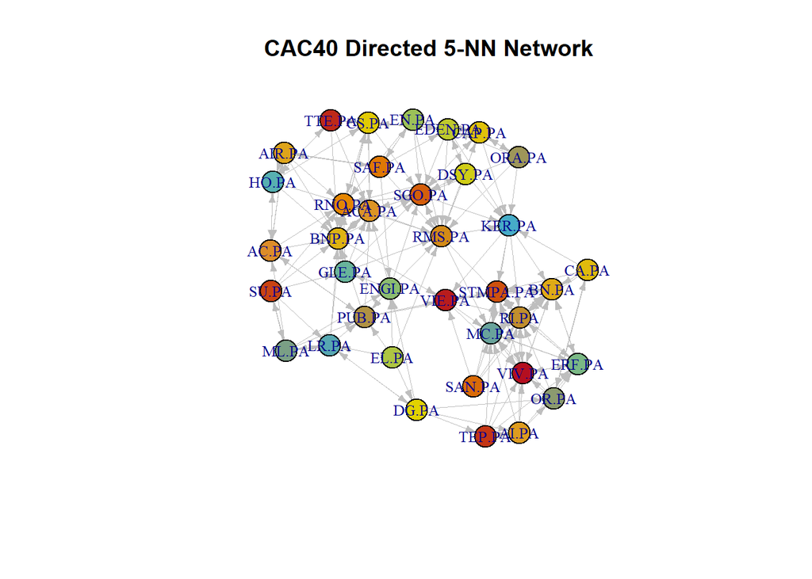

```r
# Construct the W matrix:
# Approach : k-nearest neighbours

# Alternative A: standard Euclidean distance

dist_mat1 <- as.matrix(diss(t(logDatar2[1:train.l, ]), "EUCL"))

# 5NN
k <- 5 # Choose 3, 5 or 10
Wmat1_10    <- t(sapply(1:ncol(dist_mat1), function(i) ifelse(dist_mat1[i,] < sort(dist_mat1[i,])[k+2] & dist_mat1[i,] > 0, 1/k, 0))) # k+2, because of the diagonal zero entry and the strict inequality
diag(Wmat1_10) <- 0

# Alternative B: correlation-based distance

dist_mat2 <-  as.matrix(diss(t(logDatar2[1:train.l, ]), "COR"))
#5NN
k <- 5 # Choose 3, 5 or 10
Wmat2_10    <- t(sapply(1:ncol(dist_mat2), function(i) ifelse(dist_mat2[i,] < sort(dist_mat2[i,])[k+2] & dist_mat2[i,] > 0, 1/k, 0))) # k+2, because of the diagonal zero entry and the strict inequality
diag(Wmat2_10) <- 0


# Alternative C: log-ARCH approach

dist_mat3 <- as.matrix(diss(t(logDatar2[1:train.l, ]), "AR.PIC"))

#5NN
k <- 5 # Choose 3, 5 or 10
Wmat3_10    <- t(sapply(1:ncol(dist_mat3), function(i) ifelse(dist_mat3[i,] < sort(dist_mat3[i,])[k+2] & dist_mat3[i,] > 0, 1/k, 0))) # k+2, because of the diagonal zero entry and the strict inequality
diag(Wmat3_10) <- 0


# Directed network definition

# Define node names
names <- names(Datar)

# Create a directed network object using 5-NN weight matrix
network <- tibble(
  from = names[which(Wmat3_10 > 0, arr.ind = TRUE)[,1]],
  to = names[which(Wmat3_10 > 0, arr.ind = TRUE)[,2]]
)

# Extract nonzero edges from Wmat3_10 (5-NN adjacency matrix)
edges <- which(Wmat3_10 > 0, arr.ind = TRUE)

# Create a directed graph
g1 <- graph(edges = as.vector(t(edges)), n = dim(Wmat3_10)[1], directed = TRUE)
E(g1)$color <-  "gray"
# Assign node labels and colors
V(g1)$label <- names
V(g1)$color <- wes_palette("FantasticFox1", length(V(g1)), type = "continuous")

# Use a force-directed layout (better for directed graphs)
plot(g1, layout =layout_with_kk(g1) , main = "CAC40 Directed 5-NN Network",
     edge.arrow.size = 0.4,  # Small arrows
     edge.width = 0.9,       # Thinner edges
     vertex.size = 14,        # Adjust node size for readability
     vertex.label.cex = 0.8  # Make text labels smaller
)
```

## Estimating a spatiotemporal autoregressive model

To remove the dependencies caused by temporal autocorrelation and cross-sectional spillovers in stock returns, we fit a spatial dynamic panel data (SDPD) model as the mean equation before modelling the residuals separately. We follow the SDPD specification without exogenous regressors by Lee and Yu (2012) :

$$\mathbf{Y}_t = \rho \mathbf{W}_1 \mathbf{Y}_t + \gamma \mathbf{Y}_{t-1} + \lambda \mathbf{W}_2 \mathbf{Y}_{t-1} + \mathbf{u}_t,$$

where $\rho \mathbf{W}_1 \mathbf{Y}_t$ captures contemporaneous spatial dependence, $\gamma \mathbf{Y}_{t-1}$ accounts for temporal autocorrelation, and $\lambda \mathbf{W}_2 \mathbf{Y}_{t-1}$ represents spatiotemporal spillover effects. The model residuals $\mathbf{u}_t$, referred to as `residuals` in the code.

**Show estimation function for a STAR**

```r
LL_SDPD_beta <- function( params, Y, W_1, W_2){ #param y,X,W1,W2,W3

  # theta c(rho,lambda,gamma,sigma2,beta_1,...,beta_K)

  N <- dim(Y)[1]

  t <- dim(Y)[2] # t = T + 1 (indexing R)

  rho     <- params[1]
  lambda  <- params[2]
  gamma   <- params[3]
  sigma2  <- params[4]



  S <- diag(N) - rho * W_1

  sum <- 0



  for (i in c(2:t)){

    Vt <- S %*% Y[,i] - gamma*Y[,i-1]- lambda*W_2 %*% Y[,i-1]

    sum <- sum + t(Vt) %*% Vt # sum + sum(Vt^2)

  }



  llsp <- -1 * ( -(N * (t-1) / 2) * log(2 * pi * sigma2) +

                   (t-1) * determinant(S, logarithm = TRUE)$modulus -

                   1 / (2 * sigma2) * sum )

  return(as.numeric(llsp))
}


get_residuals <- function(params, Y, W_1, W_2) {
  # theta c(rho,lambda,gamma,sigma2,beta_1,...,beta_K)

  N <- dim(Y)[1]

  t <- dim(Y)[2] # t = T + 1 (indexing R)

  rho     <- params[1]
  lambda  <- params[2]
  gamma   <- params[3]
  sigma2  <- params[4]



  S <- diag(N) - rho * W_1

  sum <- 0

  residuals <- array(NA, dim = c(N, t))

  for (i in c(2:t)){

    Vt <- S %*% Y[,i] - gamma*Y[,i-1]- lambda*W_2 %*% Y[,i-1]

    residuals[,i] <- Vt

  }

  return(residuals)
}
```

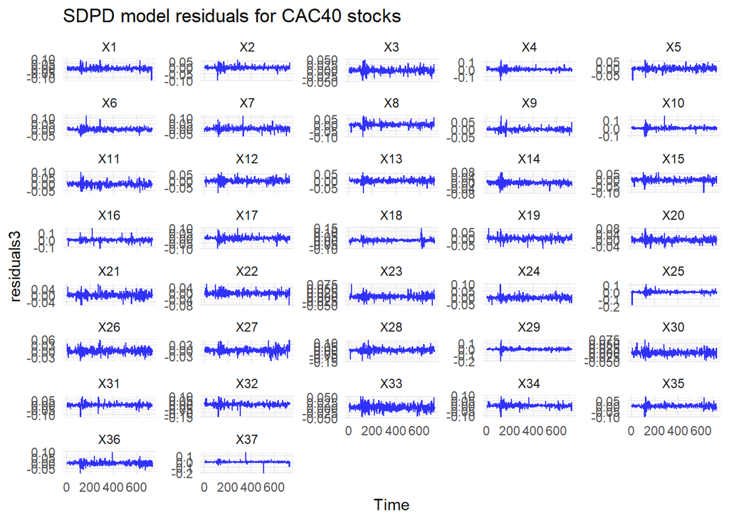

```r
# Set initial parameter values
initial_params <- c(rho = 0.01,  lambda = 0.2, gamma= 0.05, sigma2 = 0.01)

Y <- t(logDatar2[1:train.l, ])

#Maximize the function using solnp() and optim

#Picollo
result3 <- solnp(pars = initial_params, fun = LL_SDPD_beta,
                 LB = c(0.00001, 0.00001, -1, 0.00001), UB = c(0.9999, 1, 1, 10),
                 Y = Y, W_1 = Wmat3_10, W_2 = Wmat3_10, control = list(trace = 0))
#Distance
result1 <- solnp(pars = initial_params, fun = LL_SDPD_beta,
                 LB = c(0.00001, 0.00001, -1, 0.00001), UB = c(0.9999, 1, 1, 10),
                 Y = Y, W_1 = Wmat1_10, W_2 = Wmat1_10, control = list(trace = 0))
#Correlation
result2 <- solnp(pars = initial_params, fun = LL_SDPD_beta,
                 LB = c(0.00001, 0.00001, -1, 0.00001), UB = c(0.9999, 1, 1, 10),
                 Y = Y, W_1 = Wmat2_10, W_2 = Wmat2_10, control = list(trace = 0))


# Calculating the residuals
residuals3 <- get_residuals(result3$pars, Y, Wmat3_10, Wmat3_10)
residuals1 <- get_residuals(result1$pars, Y, Wmat1_10, Wmat1_10)
residuals2 <- get_residuals(result2$pars, Y, Wmat2_10, Wmat2_10)

#head(residuals3)

#Create a data frame with an additional 'Time' column to represent the sequence of dates or time points
residuals_df3 <- data.frame(Time = 1:nrow(t(residuals3)), t(residuals3))

# Melt the data frame to long format for ggplot
residuals_df_melted3 <- melt(residuals_df3, id.vars = "Time")


# Plot using ggplot2
ggplot(residuals_df_melted3, aes(x = Time, y = value)) +
  geom_line(color = "blue", alpha = 0.8) +
  labs(title = "SDPD model residuals for CAC40 stocks",
       x = "Time",
       y = "residuals3") +
  theme_minimal() +
  facet_wrap(~ variable, scales = "free_y", ncol = 5)  # Adjust ncol to control the number of columns
```

## Estimating the spatiotemporal EGARCH Model

We choose two different parameters for the leverage effect, $\theta_0$ describing the leverage effects of the contemporaneous positive and negative changes from other stocks, and $\theta_1$ for the temporal leverage effect (i.e., positive and negative changes of the same stocks in the previous period).

**Show SpEgarch estimation function**

```r
mean_abs_eps <- sqrt(2/pi)
#gamma <- 0.57721


# Numerical version to solve for epsilon
#define the function mapping y to epsilon
g <- function(y, alpha, rhoW_1, lambdaW_2, rho_1, lambda_1, theta_0, theta_1, xi, eps_lag, Y_lag){ # mapping from y to eps
  n     <- length(y)
  function_y_eps <- function(x, y, alpha, rhoW_1, lambdaW_2, rho_1, lambda_1, theta_0, theta_1, xi){
    n <- length(x)
    eps <- x
    return(    (diag(n) - lambdaW_2) %*% log(abs(y)^2) -
                 (rep(alpha,n) +
                    rhoW_1 %*% (theta_0 * eps + xi*(abs(eps) - mean_abs_eps)) +
                    rho_1 * (theta_1 * eps_lag + xi*(abs(eps_lag) - mean_abs_eps)) +
                    lambda_1 * (log(abs(Y_lag)^2) - log(abs(eps_lag)^2)) +
                    (diag(n) - lambdaW_2) %*% log(abs(eps)^2))  )
  }
  out <- nleqslv(x = y, fn = function_y_eps, alpha = alpha, rhoW_1 = rhoW_1, lambdaW_2 = lambdaW_2,
                 rho_1 = rho_1, lambda_1 = lambda_1, theta_0 = theta_0, theta_1=theta_1, xi = xi, y = y, control = list(ftol = 1e-10))
  eps <- sign(y) * abs(out$x)   #out$x
  lnh <- log(abs(y)^2) - log(abs(eps)^2)
  return(list(eps = eps, lnh =  lnh))
}


# Define the derivative of h wrt epsilon function

d_h_d_eps <- function(eps, h, alpha, theta_0, xi, rhoW_1, lambdaW_2){
  tau_eps_prime <- function(eps, theta_0, xi){
    return(theta_0 + xi*sign(eps))
  }
  n     <- length(eps)
  aux   <- solve(diag(n) - Matrix(lambdaW_2)) %*% Matrix(rhoW_1)
  eps_j <- t(array(rep(eps, n), dim = c(n, n)))
  h_i   <- array(rep(h, n), dim = c(n, n))
  return( aux %*% tau_eps_prime(eps_j, theta_0, xi) * (h_i))
}

#defining the likelihood

likelihood <- function(params,  extra_args) {

  Y <- extra_args$Y
  W_2 <- extra_args$W_2
  W_1 <- extra_args$W_1

  rho_0 <- params[1]
  rho_1 <- params[2]
  theta_0 <- params[3]
  theta_1 <- params[4]
  alpha <- params[5]
  xi <- 1
  lambda_1 <- params[6]
  lambda_0 <- params[7]
  n <- nrow(Y)
  T <- ncol(Y)
  eps_hat <- array(0.01, dim = c(n, T))

  # Compute log of the determinant of the jacobian matrix
  log_det_J <- numeric(T)
  for (t in 1:T) {
    if(t == 1){
      out <- g(Y[, t], alpha = alpha, rhoW_1 = rho_0 * W_1, lambdaW_2 = lambda_0 * W_2, theta_0 = theta_0, theta_1 = theta_1, xi = xi, rho_1 = rho_1, lambda_1 = lambda_1,
               eps_lag = rep(0.001, length(Y[, t])), Y_lag = rep(0.001, length(Y[, t])))
    } else {
      out <- g(Y[, t], alpha = alpha, rhoW_1 = rho_0 * W_1, lambdaW_2 = lambda_0 * W_2, theta_0 = theta_0, theta_1 = theta_1, xi = xi, rho_1 = rho_1, lambda_1 = lambda_1,
               eps_lag = eps_hat[,t-1], Y_lag = Y[,t-1])
    }
    eps_hat[,t] <- out$eps

    h_hat       <- exp(out$lnh)
    J <- 0.5 * (out$eps / sqrt(h_hat)) * d_h_d_eps(out$eps, h_hat, alpha, theta_0, xi, rho_0 * W_1, lambda_0 * W_2) + diag(sqrt(h_hat))
    log_det_J[t] <- determinant(J, logarithm = TRUE)$modulus
  }

  likelihood <-  sum(log(dnorm(eps_hat[,-(1:5)]))) - sum(log_det_J[-(1:5)]) #sum(log(dnorm(t(Y)%*%diag((sqrt(1/h_hat))))))

  return(-likelihood)  # Return negative likelihood for maximization
}


# Function to generate random parameters
generate_random_params <- function() {
  c(
    rho_0 = runif(1, 0, 0.3),
    rho_1 = runif(1, 0, 0.5),
    theta_0 = runif(1, -0.5, 0.51),
    theta_1 = runif(1, -0.5, 0.51),
    alpha = sd(residuals3[,-1]), #runif(1, -0.2, 0.2),
    lambda_1 = runif(1, 0, 0.5),
    lambda_0 = runif(1, 0, 0.5)
  )
}
```

## Fitting the Sp-Egarch on the CAC40 residuals

To assess model performance, we check for temporal and spatial autocorrelation in the residuals. Specifically, the Ljung-Box test is applied to each asset’s residuals and squared residuals over time, while Moran’s I test is conducted at each time point to detect spatial autocorrelation in both residuals and their squares. The plots display the corresponding p-values, with a dashed red line marking the $5\%$ significance threshold to highlight instances where residual dependencies persist.

### Piccolo-based weighted matrix

```r
##################Piccolo based weighted matrix########


extra_args3 <- list(
  Y = residuals3[,-1],
  W_2 = Wmat3_10,
  W_1 = Wmat3_10
)



set.seed(123)

# Store the results
results3 <- numeric(100)
params_list3 <- list()

for (i in 1:100) {
  params3 <- generate_random_params()
  params_list3[[i]] <- params3

  extra_args3 <- list(
    Y = residuals3[,-1],
    W_2 = Wmat3_10,
    W_1 = Wmat3_10
  )


  # Calculate negative log-likelihood
  neg_loglik <- likelihood(params3, extra_args3)
  results3[i] <- neg_loglik
}

# Find the index of the best parameters
best_index3 <- which.min(results3)
best_params3 <- params_list3[[best_index3]]
#print(best_params3)

# Define the constraint function for |lambda_0| + |lambda_1| < 1
constraint_function <- function(params) {
  lambda_0 <- params["lambda_0"]
  lambda_1 <- params["lambda_1"]
  return(abs(lambda_0) + abs(lambda_1) - 1)
}


# Run optimization with best initial parameters
resultll3 <- solnp(
  pars = best_params3,
  fun = function(params) likelihood(params, extra_args3),
  ineqfun = constraint_function,  # Adding the constraint function
  ineqLB = -Inf,  # Lower bound for the constraint (no lower bound needed)
  ineqUB = 0,     # Upper bound for the constraint (0 means abs(lambda_0) + abs(lambda_1) <= 1
  LB = c(0.0001, 0.0001, -1, -1, -10, 0.0001, 0.0001),
  UB = c(0.99, 0.999999999999, 1, 1, 10, 1, 0.95),
  control = list(trace = 0)
)


estimate3 <- resultll3$pars

cat("Results for estimate3:\n")
```

```
Results for estimate3:
```

```r
print(estimate3)
```

```
        rho_0         rho_1       theta_0       theta_1         alpha
 0.0001669205  0.2990279019  0.0081601073  0.2414854434 -1.3392674883
     lambda_1      lambda_0
 0.6670931184  0.1717154449
```

```r
# Standard error from result
#standard_error3 <- sqrt(diag(solve(resultll3$hessian[-8,-8])))

#cat("Results for standard_error3 :\n")
#print(standard_error3)


# Log-likelihood at optimum
log_likelihood_opt3 <- -resultll3$values[length(resultll3$values)]  # Use the negative log-likelihood value

# Number of estimated parameters
k <- length(resultll3$pars)

# Number of observations
n <- length(residuals3[,-1])

# Calculate AIC
AIC3 <- 2 * k - 2 * log_likelihood_opt3
cat("AIC3: ", round(AIC3, 4), "\n")
```

```
AIC3:  -148774.8
```

```r
print(AIC3)
```

```
[1] -148774.8
```

```r
# Calculate BIC
BIC3 <- log(n) * k - 2 * log_likelihood_opt3
cat("BIC3:", round(BIC3, 4), "\n")
```

```
BIC3: -148717.4
```

```r
#calcuating the squared returns
Y <- residuals3[,-1]
Y_squared <- Y^2

#calculating the estimated volatility

eps_hat3 <- array(0.01, dim = c(nrow(Y), ncol(Y)))
h_hat3 <- array(0.01, dim = c(nrow(Y), ncol(Y)))

for (t in 1:ncol(Y)) {
  if(t == 1){
    out <- g(Y[, t], alpha = resultll3$pars[5], rhoW_1 = resultll3$pars[1] * Wmat3_10, lambdaW_2 = resultll3$pars[7] * Wmat3_10, theta_0 = resultll3$pars[3], theta_1 = resultll3$pars[4], xi = 1, rho_1 = resultll3$pars[2], lambda_1 = resultll3$pars[6],
             eps_lag = rep(0.001, length(Y[, t])), Y_lag = rep(0.001, length(Y[, t])))
  } else {
    out <- g(Y[, t], alpha = resultll3$pars[5], rhoW_1 = resultll3$pars[1] * Wmat3_10, lambdaW_2 = resultll3$pars[7] * Wmat3_10, theta_0 = resultll3$pars[3], theta_1 = resultll3$pars[4], xi = 1, rho_1 = resultll3$pars[2], lambda_1 =  resultll3$pars[6],
             eps_lag = eps_hat3[,t-1], Y_lag = Y[,t-1])
  }
  eps_hat3[,t] <- out$eps

  h_hat3[,t]  <- exp(out$lnh)
}



# Ljung-Box test for residuals and the square residuals through all  series
p_values_res3 <- numeric(nrow(Y))
p_values_res_sq3 <- numeric(nrow(Y))

for (i in 1: nrow(Y) ) {

  p_values_res3[i] <- Box.test(eps_hat3[i, ])$p.value

  p_values_res_sq3[i] <- Box.test(eps_hat3[i, ]^2)$p.value
}

# percentage of significant values
percent_signi_res3 <- sum(p_values_res3 < 0.05) / nrow(Y) * 100
percent_signi_res_sq3 <- sum(p_values_res_sq3 < 0.05) / nrow(Y) * 100

cat("\nPercentage of significant p-values of Ljung-Box test for residuals and square residuals :\n")
```

```
Percentage of significant p-values of Ljung-Box test for residuals and square residuals :
```

```r
print(percent_signi_res3)
```

```
[1] 2.702703
```

```r
print(percent_signi_res_sq3)
```

```
[1] 0
```

```r
# Create the dataframe for Ljung-Box test
result_tablebox3 <- data.frame(
  Series = 1:nrow(Y),
  P_Value_Residuals3 = p_values_res3,
  P_Value_Squared_Residuals3 = p_values_res_sq3
)



# Plot the p-values for residuals
pbox3 <- ggplot(result_tablebox3, aes(x = Series)) +
  geom_point(aes(y = P_Value_Residuals3, color = "Residuals"), size = 1) +
  geom_point(aes(y = P_Value_Squared_Residuals3, color = "Squared Residuals"), size = 1) +
  geom_hline(yintercept = 0.05, linetype = "dashed", color = "red") +
  labs(
    title = "Ljung-Box CAC40 Test with Wmat3_5_NN",
    x = "Series",
    y = "P-Value",
    color = "Test data:"
  ) +
  scale_color_manual(values = c("Residuals" = "blue", "Squared Residuals" = "green")) +
  theme_minimal()  +
  theme(
    plot.title = element_text(size = 8, face = "bold"),  # Bold and larger title
    legend.title = element_text(size = 10, face = "bold"),  # Bold legend title
    legend.text = element_text(size = 10),   # Bold legend labels
    panel.background = element_rect(fill = "white", color = NA),  # Set axis background to grey
    axis.line = element_line(color = "black"),          # Make x and y axes black
    axis.ticks = element_line(color = "black"),         # Ensure axis ticks are black too
    legend.position = "bottom"
    )

#print(pbox3)




####Moran's I for residuals and square residuals at each time point

p_moran_res3 <- numeric(ncol(Y))
p_moran_res_sq3 <- numeric(ncol(Y))


for (t in 1:ncol(Y)) {
  p_moran_res3[t] <- moran.test(eps_hat3[, t], listw = mat2listw(Wmat3_10))$p.value
  p_moran_res_sq3[t] <- moran.test(eps_hat3[, t]**2, listw = mat2listw(Wmat3_10))$p.value
}

# percentage of significant values
per_mo_res3 <- sum(p_moran_res3 < 0.05) / ncol(Y) * 100
per_mo_res_sq3 <- sum(p_moran_res_sq3 < 0.05) / ncol(Y) * 100

cat("Percentage of significant p-values of Moran's I test for residuals and square residuals:\n")
```

```
Percentage of significant p-values of Moran's I test for residuals and square residuals:
```

```r
print(per_mo_res3)
```

```
[1] 0.1369863
```

```r
print(per_mo_res_sq3)
```

```
[1] 11.09589
```

```r
# Create the dataframe for the Moran's I results
result_table_mo3 <- data.frame(
  Time = 1:ncol(Y),  # Time points as columns of Y
  P_Value_Residuals_mo3 = p_moran_res3,
  P_Value_Squared_Residuals_mo3 = p_moran_res_sq3
)


# Plot the p-values for Moran's I test of residuals and squared residuals
pmo3 <- ggplot(result_table_mo3, aes(x = Time)) +
  geom_point(aes(y = P_Value_Residuals_mo3, color = "Residuals"), size = 1) +
  geom_point(aes(y = P_Value_Squared_Residuals_mo3, color = "Squared Residuals"), size = 1) +
  geom_hline(yintercept = 0.05, linetype = "dashed", color = "red") +
  labs(
    title = "Moran's I Test CAC40 with Wmat3_5_NN",
    x = "Time",
    y = "P-Value",
    color = "Test data"
  ) +
  scale_color_manual(values = c("Residuals" = "blue", "Squared Residuals" = "green")) +
  theme_minimal()  +
  theme(
    plot.title = element_text(size = 8, face = "bold"),  # Bold and larger title
    legend.title = element_text(size = 10, face = "bold"),  # Bold legend title
    legend.text = element_text(size = 10),   # Bold legend labels
    panel.background = element_rect(fill = "white", color = NA),  # Set axis background to grey
    axis.line = element_line(color = "black"),          # Make x and y axes black
    axis.ticks = element_line(color = "black"),         # Ensure axis ticks are black too
    legend.position = "bottom"

  )

#print(pmo3)
```

### Distance based weighted matrix

```r
########distance based weighted matrix#######
extra_args1 <- list(
  Y = residuals1[,-1],
  W_2 = Wmat1_10,
  W_1 = Wmat1_10
)

set.seed(123)

# Store the results
results1 <- numeric(100)
params_list1 <- list()

for (i in 1:100) {
  params1 <- generate_random_params()
  params_list1[[i]] <- params1

  extra_args1 <- list(
    Y = residuals1[,-1],
    W_2 = Wmat1_10,
    W_1 = Wmat1_10
  )

  # Calculate negative log-likelihood
  neg_loglik <- likelihood(params1, extra_args1)
  results1[i] <- neg_loglik
}

# Find the index of the best parameters
best_index1 <- which.min(results1)
best_params1 <- params_list1[[best_index1]]
#print(best_params1)

# Run optimization with best initial parameters
resultll1 <- solnp(
  pars = best_params1,
  fun = function(params) likelihood(params, extra_args1),
  ineqfun = constraint_function,  # Adding the constraint function
  ineqLB = -Inf,  # Lower bound for the constraint (no lower bound needed)
  ineqUB = 0,     # Upper bound for the constraint (0 means abs(lambda_0) + abs(lambda_1) <= 1
  LB = c(0.0001, 0.0001, -1, -1, -10, 0.0001, 0.0001),
  UB = c(0.99, 0.999999999999, 1, 1, 10, 1, 0.99),
  control = list(trace = 0)
)

estimate1 <- resultll1$pars

cat("Result for estimate1 :\n")
```

```
Result for estimate1 :
```

```r
print(estimate1)
```

```
      rho_0       rho_1     theta_0     theta_1       alpha    lambda_1
 0.13838371  0.38516871  0.06738003 -0.03833190 -0.43147140  0.59092210
   lambda_0
 0.35022273
```

```r
# Standard error
#standard_error1 <- sqrt(diag(solve(resultll1$hessian[-8,-8])))

#cat("Result for standard_error1 :\n")
#print(standard_error1)

# Log-likelihood at optimum
log_likelihood_opt1 <- -resultll1$values[length(resultll1$values)]  # Use the negative log-likelihood value

# Number of estimated parameters
k <- length(resultll1$pars)

# Number of observations
n <- length(t(logDatar2[1:train.l, ]))

# Calculate AIC
AIC1 <- 2 * k - 2 * log_likelihood_opt1
cat("AIC1: ", round(AIC1, 4), "\n")
```

```
AIC1:  -154388.5
```

```r
# Calculate BIC
BIC1 <- log(n) * k - 2 * log_likelihood_opt1
cat("BIC1:", round(BIC1, 4), "\n")
```

```
BIC1: -154331.1
```

```r
#calcuating the squared returns
Y <- residuals1[,-1]
Y_squared <- Y^2

#calculating the estimated volatility

eps_hat1 <- array(0.01, dim = c(nrow(Y), ncol(Y)))
h_hat1 <- array(0.01, dim = c(nrow(Y), ncol(Y)))

for (t in 1:ncol(Y)) {
  if(t == 1){
    out <- g(Y[, t], alpha = resultll1$pars[5], rhoW_1 = resultll1$pars[1] * Wmat1_10, lambdaW_2 = resultll1$pars[7] * Wmat1_10, theta_0 = resultll1$pars[3], theta_1 = resultll1$pars[4], xi = 1, rho_1 = resultll1$pars[2], lambda_1 = resultll1$pars[6],
             eps_lag = rep(0.001, length(Y[, t])), Y_lag = rep(0.001, length(Y[, t])))
  } else {
    out <- g(Y[, t], alpha = resultll1$pars[5], rhoW_1 = resultll1$pars[1] * Wmat1_10, lambdaW_2 = resultll1$pars[7] * Wmat1_10, theta_0 = resultll1$pars[3], theta_1 = resultll1$pars[4], xi = 1, rho_1 = resultll1$pars[2], lambda_1 =  resultll1$pars[6],
             eps_lag = eps_hat1[,t-1], Y_lag = Y[,t-1])
  }
  eps_hat1[,t] <- out$eps

  h_hat1[,t]  <- exp(out$lnh)
}



# Ljung-Box test for residuals and the square residuals through all  series
p_values_res1 <- numeric(nrow(Y))
p_values_res_sq1 <- numeric(nrow(Y))

for (i in 1: nrow(Y) ) {

  p_values_res1[i] <- Box.test(eps_hat1[i, ])$p.value

  p_values_res_sq1[i] <- Box.test(eps_hat1[i, ]^2)$p.value
}

# percentage of significant values
percent_signi_res1 <- sum(p_values_res1 < 0.05) / nrow(Y) * 100
percent_signi_res_sq1 <- sum(p_values_res_sq1 < 0.05) / nrow(Y) * 100

cat("Percentage of significant p-values of Ljung-Box test for residuals and square residuals :\n")
```

```
Percentage of significant p-values of Ljung-Box test for residuals and square residuals :
```

```r
print(percent_signi_res1)
```

```
[1] 5.405405
```

```r
print(percent_signi_res_sq1)
```

```
[1] 2.702703
```

```r
# Create the dataframe for Ljung-Box test
result_tablebox1 <- data.frame(
  Series = 1:nrow(Y),
  P_Value_Residuals1 = p_values_res1,
  P_Value_Squared_Residuals1 = p_values_res_sq1
)


# Plot the p-values for residuals
pbox1 <- ggplot(result_tablebox1, aes(x = Series)) +
  geom_point(aes(y = P_Value_Residuals1, color = "Residuals"), size = 1) +
  geom_point(aes(y = P_Value_Squared_Residuals1, color = "Squared Residuals"), size = 1) +
  geom_hline(yintercept = 0.05, linetype = "dashed", color = "red") +
  labs(
    title = "Ljung-Box CAC40 with Wmat1_5_NN",
    x = "Series",
    y = "P-Value",
    color = "Data type"
  ) +
  scale_color_manual(values = c("Residuals" = "blue", "Squared Residuals" = "green")) +
  theme_minimal()  +
  theme(
    plot.title = element_text(size = 8, face = "bold"),  # Bold and larger title
    legend.title = element_text(size = 10, face = "bold"),  # Bold legend title
    legend.text = element_text(size = 10),   # Bold legend labels
    panel.background = element_rect(fill = "white", color = NA),  # Set axis background to grey
    axis.line = element_line(color = "black"),          # Make x and y axes black
    axis.ticks = element_line(color = "black"),          # Ensure axis ticks are black too
    legend.position = "none"
  )

#print(pbox1)



####Moran's I for residuals and square residuals at each time point
p_moran_res1 <- numeric(ncol(Y))
p_moran_res_sq1 <- numeric(ncol(Y))


for (t in 1:ncol(Y)) {
  p_moran_res1[t] <- moran.test(eps_hat1[, t], listw = mat2listw(Wmat1_10))$p.value
  p_moran_res_sq1[t] <- moran.test(eps_hat1[, t]**2, listw = mat2listw(Wmat1_10))$p.value
}

# percentage of significant values
per_mo_res1 <- sum(p_moran_res1 < 0.05) / ncol(Y) * 100
per_mo_res_sq1 <- sum(p_moran_res_sq1 < 0.05) / ncol(Y) * 100

cat("Percentage of significant p-values of Moran's I test for residuals and square residuals:\n")
```

```
Percentage of significant p-values of Moran's I test for residuals and square residuals:
```

```r
print(per_mo_res1)
```

```
[1] 5.753425
```

```r
print(per_mo_res_sq1)
```

```
[1] 7.534247
```

```r
# Create the dataframe for the Moran's I results
result_table_mo1 <- data.frame(
  Time = 1:ncol(Y),  # Time points as columns of Y
  P_Value_Residuals_mo1 = p_moran_res1,
  P_Value_Squared_Residuals_mo1 = p_moran_res_sq1
)



# Plot the p-values for Moran's I test of residuals and squared residuals
pmo1 <- ggplot(result_table_mo1, aes(x = Time)) +
  geom_point(aes(y = P_Value_Residuals_mo1, color = "Residuals"), size = 1) +
  geom_point(aes(y = P_Value_Squared_Residuals_mo1, color = "Squared Residuals"), size = 1) +
  geom_hline(yintercept = 0.05, linetype = "dashed", color = "red") +
  labs(
    title = "Moran's I CAC40 with Wmat1_5_NN",
    x = "Time",
    y = "P-Value",
    color = "Data type"
  ) +
  scale_color_manual(values = c("Residuals" = "blue", "Squared Residuals" = "green")) +
  theme_minimal()  +
  theme(
    plot.title = element_text(size = 8, face = "bold"),  # Bold and larger title
    legend.title = element_text(size = 10, face = "bold"),  # Bold legend title
    legend.text = element_text(size = 10),   # Bold legend labels
    panel.background = element_rect(fill = "white", color = NA),  # Set axis background to grey
    axis.line = element_line(color = "black"),          # Make x and y axes black
    axis.ticks = element_line(color = "black"),          # Ensure axis ticks are black too
    legend.position = "none"
  )

#print(pmo1)
```

### Correlation based weighted matrix

```r
##################correlation based weighted matrix########

extra_args2 <- list(
  Y = residuals2[,-1],
  W_2 = Wmat2_10,
  W_1 = Wmat2_10
)


set.seed(123)


# Store the results
results2 <- numeric(100)
params_list2 <- list()

for (i in 1:100) {
  params2 <- generate_random_params()
  params_list2[[i]] <- params2

  extra_args2 <- list(
    Y = residuals2[,-1],
    W_2 = Wmat2_10,
    W_1 = Wmat2_10
  )


  # Calculate negative log-likelihood
  neg_loglik <- likelihood(params2, extra_args2)
  results2[i] <- neg_loglik
}

# Find the index of the best parameters
best_index2 <- which.min(results2)
best_params2 <- params_list2[[best_index2]]
#print(best_params2)


# Run optimization with best initial parameters
resultll2 <- solnp(
  pars = best_params2,
  fun = function(params) likelihood(params, extra_args2),
  ineqfun = constraint_function,  # Adding the constraint function
  ineqLB = -Inf,  # Lower bound for the constraint (no lower bound needed)
  ineqUB = 0,     # Upper bound for the constraint (0 means abs(lambda_0) + abs(lambda_1) <= 1
  LB = c(0.0001, 0.0001, -1, -1, -10, 0.0001, 0.0001),
  UB = c(0.99, 0.999999999999, 1, 1, 10, 1, 0.99),
  control = list(trace = 0)
)


estimate2 <- resultll2$pars
cat("Result for estimate2 :\n")
```

```
Result for estimate2 :
```

```r
print(estimate2)
```

```
        rho_0         rho_1       theta_0       theta_1         alpha
 0.0003112562  0.4058590029  0.8106251332  0.0644529503 -0.9736362377
     lambda_1      lambda_0
 0.6285746898  0.2543184880
```

```r
# Standard from the result
#standard_error2 <- sqrt(diag(solve(resultll2$hessian[-8,-8])))

#cat("Result for standard_error2 :\n")
#print(standard_error2)


# Log-likelihood at optimum
log_likelihood_opt2 <- -resultll2$values[length(resultll2$values)]  # Use the negative log-likelihood value

# Number of estimated parameters
k <- length(resultll2$pars)

# Number of observations
n <- length(logDatar2[1:train.l, ])

# Calculate AIC
AIC2 <- 2 * k - 2 * log_likelihood_opt2

cat("AIC2:", round(AIC2, 4), "\n")
```

```
AIC2: -155465.2
```

```r
# Calculate BIC
BIC2 <- log(n) * k - 2 * log_likelihood_opt2
cat("BIC2:", round(BIC2, 4), "\n")
```

```
BIC2: -155453.9
```

```r
#calcuating the squared returns
Y <- residuals2[,-1]
Y_squared <- Y^2

#calculating the estimated volatility

eps_hat2 <- array(0.01, dim = c(nrow(Y), ncol(Y)))
h_hat2 <- array(0.01, dim = c(nrow(Y), ncol(Y)))

for (t in 1:ncol(Y)) {
  if(t == 1){
    out <- g(Y[, t], alpha = resultll2$pars[5], rhoW_1 = resultll2$pars[1] * Wmat2_10, lambdaW_2 = resultll2$pars[7] * Wmat2_10, theta_0 = resultll2$pars[3], theta_1 = resultll2$pars[4], xi = 1, rho_1 = resultll2$pars[2], lambda_1 = resultll2$pars[6],
             eps_lag = rep(0.001, length(Y[, t])), Y_lag = rep(0.001, length(Y[, t])))
  } else {
    out <- g(Y[, t], alpha = resultll2$pars[5], rhoW_1 = resultll2$pars[1] * Wmat2_10, lambdaW_2 = resultll2$pars[7] * Wmat2_10, theta_0 = resultll2$pars[3], theta_1 = resultll2$pars[4], xi = 1, rho_1 = resultll2$pars[2], lambda_1 =  resultll2$pars[6],
             eps_lag = eps_hat2[,t-1], Y_lag = Y[,t-1])
  }
  eps_hat2[,t] <- out$eps

  h_hat2[,t]  <- exp(out$lnh)
}



# Ljung-Box test for residuals and the square residuals through all  series
p_values_res2 <- numeric(nrow(Y))
p_values_res_sq2 <- numeric(nrow(Y))

for (i in 1: nrow(Y) ) {

  p_values_res2[i] <- Box.test(eps_hat2[i, ])$p.value

  p_values_res_sq2[i] <- Box.test(eps_hat2[i, ]^2)$p.value
}

# percentage of significant values
percent_signi_res2 <- sum(p_values_res2 < 0.05) / nrow(Y) * 100
percent_signi_res_sq2 <- sum(p_values_res_sq2 < 0.05) / nrow(Y) * 100

cat("Percentage of significant p-values of Ljung-Box test for residuals and square residuals:\n")
```

```
Percentage of significant p-values of Ljung-Box test for residuals and square residuals:
```

```r
print(percent_signi_res2)
```

```
[1] 10.81081
```

```r
print(percent_signi_res_sq2)
```

```
[1] 0
```

```r
# Create the dataframe for Ljung-Box test
result_tablebox2 <- data.frame(
  Series = 1:nrow(Y),
  P_Value_Residuals2 = p_values_res2,
  P_Value_Squared_Residuals2 = p_values_res_sq2
)



# Plot the p-values for residuals
pbox2 <- ggplot(result_tablebox2, aes(x = Series)) +
  geom_point(aes(y = P_Value_Residuals2, color = "Residuals"), size = 2) +
  geom_point(aes(y = P_Value_Squared_Residuals2, color = "Squared Residuals"), size = 2) +
  geom_hline(yintercept = 0.05, linetype = "dashed", color = "red") +
  labs(
    title = "Ljung-Box CAC40 with Wmat2_5_NN",
    x = "Series",
    y = "P-Value",
    color = "Data type"
  ) +
  scale_color_manual(values = c("Residuals" = "blue", "Squared Residuals" = "green")) +
  theme_minimal()  +
  theme(
    plot.title = element_text(size = 8, face = "bold"),  # Bold and larger title
    legend.title = element_text(size = 10, face = "bold"),  # Bold legend title
    legend.text = element_text(size = 10),   # Bold legend labels
    panel.background = element_rect(fill = "white", color = NA),  # Set axis background to grey
    axis.line = element_line(color = "black"),          # Make x and y axes black
    axis.ticks = element_line(color = "black"),          # Ensure axis ticks are black too
    legend.position = "none"
  )

#print(pbox2)



####Moran's I for residuals and square residuals at each time point
p_moran_res2 <- numeric(ncol(Y))
p_moran_res_sq2 <- numeric(ncol(Y))


for (t in 1:ncol(Y)) {
  p_moran_res2[t] <- moran.test(eps_hat2[, t], listw = mat2listw(Wmat2_10))$p.value
  p_moran_res_sq2[t] <- moran.test(eps_hat2[, t]**2, listw = mat2listw(Wmat2_10))$p.value
}

# percentage of significant values
per_mo_res2 <- sum(p_moran_res2 < 0.05) / ncol(Y) * 100
per_mo_res_sq2 <- sum(p_moran_res_sq2 < 0.05) / ncol(Y) * 100

cat("Percentage of significant p-values of Moran's I test for residuals and square residuals:\n")
```

```
Percentage of significant p-values of Moran's I test for residuals and square residuals:
```

```r
print(per_mo_res2)
```

```
[1] 5.205479
```

```r
print(per_mo_res_sq2)
```

```
[1] 9.863014
```

```r
# Create the dataframe for the Moran's I results
result_table_mo2 <- data.frame(
  Time = 1:ncol(Y),  # Time points as columns of Y
  P_Value_Residuals_mo2 = p_moran_res2,
  P_Value_Squared_Residuals_mo2 = p_moran_res_sq2
)



# Plot the p-values for Moran's I test of residuals and squared residuals
pmo2 <- ggplot(result_table_mo2, aes(x = Time)) +
  geom_point(aes(y = P_Value_Residuals_mo2, color = "Residuals"), size = 2) +
  geom_point(aes(y = P_Value_Squared_Residuals_mo2, color = "Squared Residuals"), size = 2) +
  geom_hline(yintercept = 0.05, linetype = "dashed", color = "red") +
  labs(
    title = "Moran's I Test CAC40 with Wmat2_5_NN",
    x = "Time",
    y = "P-Value",
    color = "Data type"
  ) +
  scale_color_manual(values = c("Residuals" = "blue", "Squared Residuals" = "green")) +
  theme_minimal()  +
  theme(
    plot.title = element_text(size = 8, face = "bold"),  # Bold and larger title
    legend.title = element_text(size = 10, face = "bold"),  # Bold legend title
    legend.text = element_text(size = 10),   # Bold legend labels
    panel.background = element_rect(fill = "white", color = NA),  # Set axis background to grey
    axis.line = element_line(color = "black"),          # Make x and y axes black
    axis.ticks = element_line(color = "black"),          # Ensure axis ticks are black too
    legend.position = "none"
  )

#print(pmo2)
```

### Combined plots :

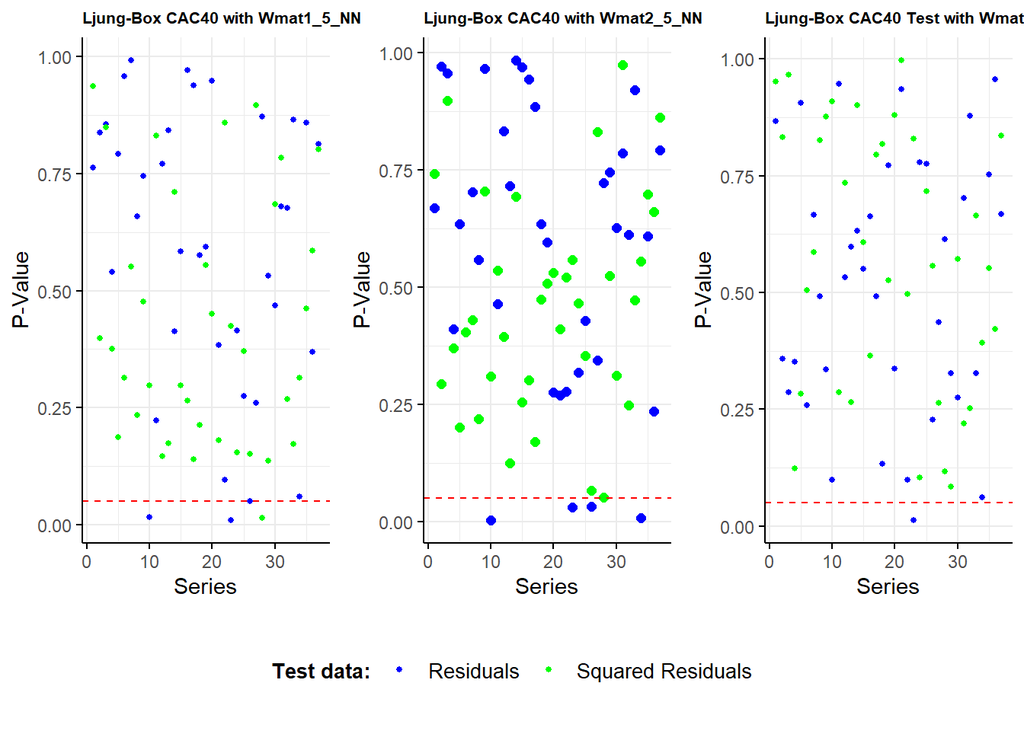

```r
##combine plots

# Function to extract legend
get_legend <- function(plot) {
  ggplotGrob(plot)$grobs[[which(sapply(ggplotGrob(plot)$grobs, function(x) x$name) == "guide-box")]]
}

###for Ljung-Box test
legend <- get_legend(pbox3)  # Extract legend from pbox3

# Remove individual legends
pbox3 <- pbox3 + theme(legend.position = "none")

# Arrange plots in one row with shared legend below
grid.arrange(
  arrangeGrob(pbox1, pbox2, pbox3, ncol = 3),
  legend,
  nrow = 2,
  heights = c(5, 1)  # Adjust legend height
)
```

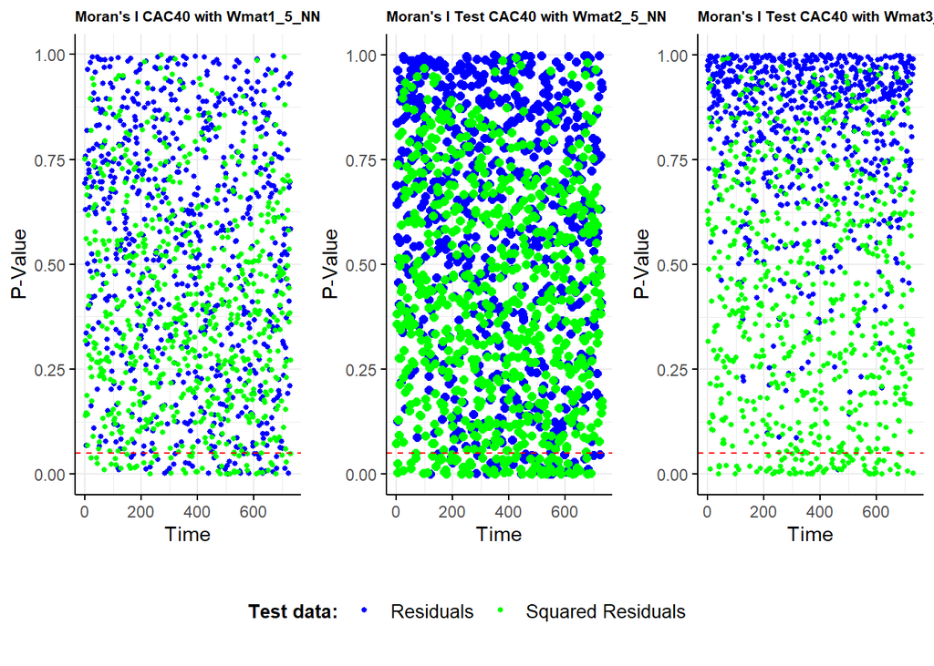

```r
### for Moran's test


legend2 <- get_legend(pmo3)  # Extract legend from pbox3

# Remove individual legends
pmo3 <- pmo3 + theme(legend.position = "none")

# Arrange plots in one row with shared legend below
grid.arrange(
  arrangeGrob(pmo1, pmo2, pmo3, ncol = 3),
  legend,
  nrow = 2,
  heights = c(5, 1)  # Adjust legend height
)
```

## References

Lee, Lung-fei, and Jihai Yu. 2012. “QML Estimation of Spatial Dynamic Panel Data Models with Time Varying Spatial Weights Matrices.” *Spatial Economic Analysis* 7 (1): 31–74.

Mattera, Raffaele, and Philipp Otto. 2024. “Network Log-ARCH Models for Forecasting Stock Market Volatility.” *International Journal of Forecasting*.